# Reproducible Research Assignment 1

Loading library and data set and preprocessing the data

```r
library(ggplot2)
library(scales)
library(lattice)
data <- read.csv("activity.csv")
names(data)
```

```
## [1] "steps"    "date"     "interval"
```

```r
str(data)
```

```
## 'data.frame':    17568 obs. of  3 variables:
##  $ steps   : int  NA NA NA NA NA NA NA NA NA NA ...
##  $ date    : Factor w/ 61 levels "2012-10-01","2012-10-02",..: 1 1 1 1 1 1 1 1 1 1 ...
##  $ interval: int  0 5 10 15 20 25 30 35 40 45 ...
```

Keep the original data as “data”, then make a copy, as “data1”

```r
data1 <- data
```

Calculte the total number of steps taken per day. For this part of the work, ignore the missing values in the dataset.

```r
sumofsteps <- aggregate(data$steps, by=list(data$date), FUN=sum)
```

Make a histogram of the total number of steps taken each day

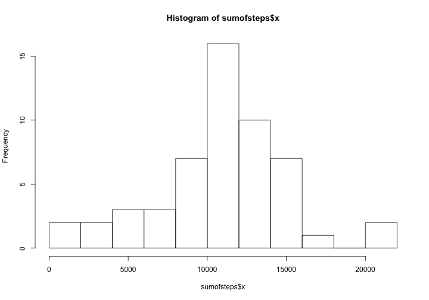

```r
hist(sumofsteps$x, breaks = 10)
```

Calculate and report the mean and median total number of steps taken per day

```r
mean(sumofsteps$x)
```

```
## [1] NA
```

```r
mean(sumofsteps$x, na.rm = TRUE)
```

```
## [1] 10766
```

```r
median(sumofsteps$x)
```

```
## [1] NA
```

```r
median(sumofsteps$x, na.rm = TRUE)
```

```
## [1] 10765
```

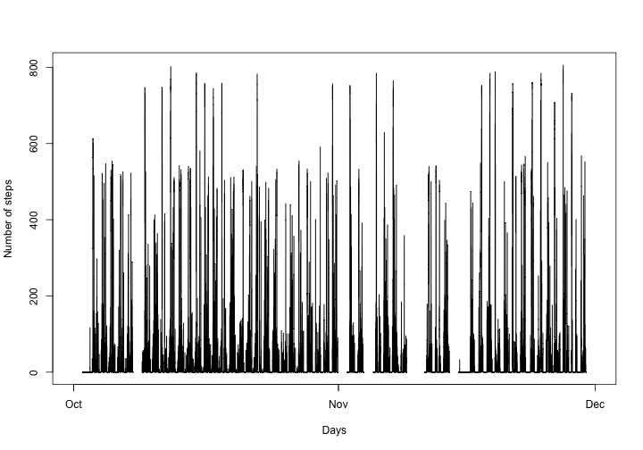

```r
data$date <- as.Date(data$date)
data$time <- paste(data$interval%/%100,data$interval%%100, "00", sep=":")
data$DateTime <- paste(data$date, data$time)
data$DateTime <- as.POSIXlt(data$DateTime)
plot(data$DateTime, data$steps, type = "l", xlab = "Days", ylab = "Number of steps")
```

Imputing missing values Check for the missing value in the columns, “steps”, “date” and “iterval”

```r
nrow(data)
```

```
## [1] 17568
```

```r
length(data$steps[!is.na(data$steps)])
```

```
## [1] 15264
```

```r
length(data$date[!is.na(data$date)])
```

```
## [1] 17568
```

```r
length(data$interval[!is.na(data$interval)])
```

```
## [1] 17568
```

It is clear that only the column “steps” has missing value. Calculate the total number of rows with NAs

```r
length(data$date[!is.na(data$date)]) - length(data$steps[!is.na(data$steps)])
```

```
## [1] 2304
```

```r
for(i in 1:nrow(data)){
    if(is.na(data$steps[i])){
        data$steps[i] = 0
    }
}
for(j in 1:nrow(data)){
    if(data$steps[j] == max(data$steps)){
        print(data[j,])
    }
}
```

```
##       steps       date interval    time            DateTime
## 16492   806 2012-11-27      615 6:15:00 2012-11-27 06:15:00
```

```r
head(data1)
```

```
##   steps       date interval
## 1    NA 2012-10-01        0
## 2    NA 2012-10-01        5
## 3    NA 2012-10-01       10
## 4    NA 2012-10-01       15
## 5    NA 2012-10-01       20
## 6    NA 2012-10-01       25
```

```r
for(i in 1:nrow(data1)){
    if(is.na(data1$steps[i])){
        data1$steps[i] = 0
    }
}
head(data1)
```

```
##   steps       date interval
## 1     0 2012-10-01        0
## 2     0 2012-10-01        5
## 3     0 2012-10-01       10
## 4     0 2012-10-01       15
## 5     0 2012-10-01       20
## 6     0 2012-10-01       25
```

Make a histogram of the total number of steps taken each day and Calculate and report the mean and median total number of steps taken per day.

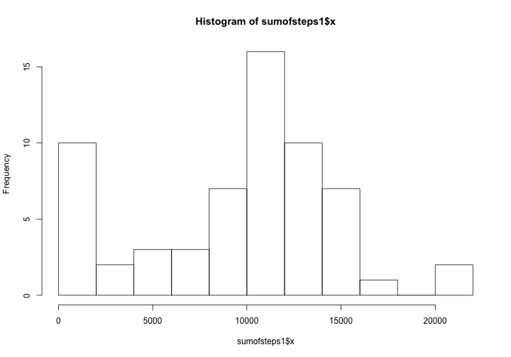

```r
sumofsteps1 <- aggregate(data1$steps, by=list(data1$date), FUN=sum)
hist(sumofsteps1$x, breaks = 10)
```

```r
mean(sumofsteps1$x)
```

```
## [1] 9354
```

```r
median(sumofsteps1$x)
```

```
## [1] 10395
```

Do these values differ from the estimates from the first part of the assignment? What is the impact of imputing missing data on the estimates of the total daily number of steps?

There are some different between the two histogram, and the mean and median are different too.

We will check whether there are differences in activity patterns between weekdays and weekends

Create a new factor variable in the dataset with two levels – “weekday” and “weekend” indicating whether a given date is a weekday or weekend day.

```r
data1$date <- as.Date(data$date)
days <- !(weekdays(data$date) %in% c('Saturday','Sunday'))
data1$day <- days
for(i in 1:nrow(data1)){
    if(data1$day[i]){
        data1$weekdays[i] = "weekdays"
    }
    else{
        data1$weekdays[i] = "weekend"
    }
}
```

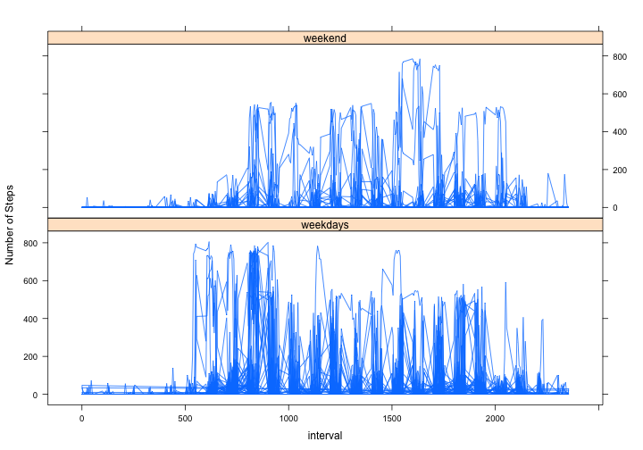

```r
xyplot( steps ~ interval | weekdays, type = "l", data = data1, ylab = "Number of Steps", layout = c(1,2))
```